# Final Exam - 175 Points

## 3. Inference

Next, we would like to determine if we have sufficient evidence to suggest that there is an association between **breast tumor diagnosis** and tissue sample **smoothness_mean** for ALL breast tumors.

We will do this by determining whether we have sufficient evidence to suggest that the average smoothness mean of ALL benign breast tumors is different from the average smoothness mean of ALL malignant breast tumors.

### 3.1. Hypotheses

Set up your hypotheses for this analysis. Make sure you define any parameters that you use.

### 3.2. Conditions

Check the conditions for conducting this hypothesis test.

The sample size is greater than 30 and the sample is randomly collected

### 3.3. Test Statistic

Calculate the test statistic for this hypothesis test.

```python
df_benign = dfc[dfc['diagnosis'] == 'B'].reset_index(drop=True)
df_malignant = dfc[dfc['diagnosis'] == 'M'].reset_index(drop=True)
```

```python
dfbm = df_benign['smoothness_mean'].mean()
dfbstd = df_benign['smoothness_mean'].std()
dfmm = df_malignant['smoothness_mean'].mean()
dfmstd = df_malignant['smoothness_mean'].std()
```

```python
test_stat = ((dfbm-dfmm) - 0) / np.sqrt((dfbstd**2)/len(df_benign) + (dfmstd**2)/len(df_malignant))
test_stat
```

```
-9.19494177347912
```

### 3.5. p-value

Calculate the p-value for this hyopthesis test.

```python
pvalue = 2*(1-t.cdf(np.abs(test_stat), df=145))
pvalue
```

```
4.440892098500626e-16
```

### 3.6. Conclusion

Use your p-value and a significance level of $\alpha=0.05$ to make a conclusion about your hypotheses.

Since the p-value is lower than the significance level, we reject the null hypothesis, which means there is sufficient evidence to suggest that there is an association between breast tumor diagnosis and tissue sample smoothness_mean for all breast tumors.

### 3.7. Conceptual Question - Decreasing Sample Size

What if everything from our previous analysis (statistics, calculations, etc.) had remained unchanged *except our sample of benign tumors were to decrease*. Would this change make it more or less likely for us to reject the null hypothesis? Explain.

### 3.8. Putting the p-value into Words

Put the p-value that you just calculated in 3.6 *into words in the context of this problem*. Select from one of the options below.

a. The probability that the average smoothness mean of ALL benign breast tumors is **equal to** the average smoothness mean of ALL malignant breast tumors.

b. The probability that the average smoothness mean of ALL benign breast tumors is **not equal to** the average smoothness mean of ALL malignant breast tumors.

c. The probability of collecting random samples of benign and malignant breast tumors in which $\bar{x}_b-\bar{x}_m\leq -0.74$ OR $\bar{x}_b-\bar{x}_m\geq 0.74$ **GIVEN THAT** the average smoothness mean of ALL benign breast tumors is **not equal to** the average smoothness mean of ALL malignant breast tumors.

d. The probability of collecting random samples of benign and malignant breast tumors in which $\bar{x}_b-\bar{x}_m\leq -0.74$ **GIVEN THAT** the average smoothness mean of ALL benign breast tumors is **equal to** the average smoothness mean of ALL malignant breast tumors.

e. None of options (a)-(d) above are correct definitions of this p-value.

## 4. Logistic Regression

Next, we would like to build a logistic regression model that will be effective at predicting **the probability that a breast tumor is malignant** *for new datasets*. Simultaneously, we would also like to use this model to determine which of our 10 physical attributes carry the most predictive power when it comes to predicting whether a breast tumor is malignant or benign.

### 4.1. Dataframe Manipulation

First, let's get our dataframes into the appropriate format for the analyses that we will conduct below.

#### 4.1.1. 0/1 Response Variable

First, create a 0/1 response variable in your dataframe that is equal to 1 if the tumor is malignant and 0 if the tumor is benign.

```python
dfc['y']=1*(dfc['diagnosis']=='M')
dfc
```

|  | diagnosis | radius_mean | texture_mean | perimeter_mean | area_mean | smoothness_mean | compactness_mean | concavity_mean | concavepoints_mean | symmetry_mean | fractal_dimension_mean | y |
| --- | --- | --- | --- | --- | --- | --- | --- | --- | --- | --- | --- | --- |
| 0 | M | 1.097064 | -2.073335 | 1.269934 | 0.984375 | 1.568466 | 3.283515 | 2.652874 | 2.532475 | 2.217515 | 2.255747 | 1 |
| 1 | M | 1.829821 | -0.353632 | 1.685955 | 1.908708 | -0.826962 | -0.487072 | -0.023846 | 0.548144 | 0.001392 | -0.868652 | 1 |
| 2 | M | 1.579888 | 0.456187 | 1.566503 | 1.558884 | 0.942210 | 1.052926 | 1.363478 | 2.037231 | 0.939685 | -0.398008 | 1 |
| 3 | M | -0.768909 | 0.253732 | -0.592687 | -0.764464 | 3.283553 | 3.402909 | 1.915897 | 1.451707 | 2.867383 | 4.910919 | 1 |
| 4 | M | 1.750297 | -1.151816 | 1.776573 | 1.826229 | 0.280372 | 0.539340 | 1.371011 | 1.428493 | -0.009560 | -0.562450 | 1 |
| ... | ... | ... | ... | ... | ... | ... | ... | ... | ... | ... | ... | ... |
| 564 | M | 2.110995 | 0.721473 | 2.060786 | 2.343856 | 1.041842 | 0.219060 | 1.947285 | 2.320965 | -0.312589 | -0.931027 | 1 |
| 565 | M | 1.704854 | 2.085134 | 1.615931 | 1.723842 | 0.102458 | -0.017833 | 0.693043 | 1.263669 | -0.217664 | -1.058611 | 1 |
| 566 | M | 0.702284 | 2.045574 | 0.672676 | 0.577953 | -0.840484 | -0.038680 | 0.046588 | 0.105777 | -0.809117 | -0.895587 | 1 |
| 567 | M | 1.838341 | 2.336457 | 1.982524 | 1.735218 | 1.525767 | 3.272144 | 3.296944 | 2.658866 | 2.137194 | 1.043695 | 1 |
| 568 | B | -1.808401 | 1.221792 | -1.814389 | -1.347789 | -3.112085 | -1.150752 | -1.114873 | -1.261820 | -0.820070 | -0.561032 | 0 |

556 rows × 12 columns

#### 4.1.2. Training and Test Dataset

Next, randomly split your dataframe into a training dataset and a test dataset. Your training dataset should be 85% of the of the observations. Use a random state of 721.

```python
df_train, df_test = train_test_split(dfc, test_size = 0.15, random_state = 721)
```

#### 4.1.3. Features Training Matrix, Training Target Array, Features Test Matrix, Test Target Array

Next, for this logistic regression model

- use your training dataset to create a training features matrix and training target array, and
- use your test dataset to create a test features matrix and test target array.

```python
y = dfc['y']
X = dfc.drop(columns='y')

X_train, X_test, y_train, y_test = train_test_split(X, y, test_size = 0.15, random_state = 721)
X_train
```

|  | diagnosis | radius_mean | texture_mean | perimeter_mean | area_mean | smoothness_mean | compactness_mean | concavity_mean | concavepoints_mean | symmetry_mean | fractal_dimension_mean |
| --- | --- | --- | --- | --- | --- | --- | --- | --- | --- | --- | --- |
| 438 | B | -0.078755 | 0.072221 | -0.135476 | -0.177157 | -0.677515 | -0.777787 | -0.946385 | -0.670364 | -0.936900 | -0.860147 |
| 511 | B | 0.193899 | -1.068042 | 0.110841 | 0.073409 | -0.828386 | -1.026810 | -0.685995 | -0.606394 | -0.557202 | -1.320868 |
| 373 | M | 1.849702 | -0.451369 | 1.764216 | 1.934305 | -0.135234 | 0.061763 | 0.802271 | 1.044420 | -0.878485 | -1.136580 |
| 68 | B | -1.447987 | -0.456023 | -1.366651 | -1.150124 | 0.728714 | 0.700428 | 2.814833 | -0.133333 | 1.093024 | 2.503828 |
| 306 | B | -0.263364 | -0.807410 | -0.325363 | -0.334435 | -0.800631 | -0.982274 | -1.096530 | -1.177705 | -0.655777 | -0.546856 |
| ... | ... | ... | ... | ... | ... | ... | ... | ... | ... | ... | ... |
| 257 | M | 0.338746 | -0.469986 | 0.462606 | 0.166127 | 2.643065 | 2.351102 | 1.958584 | 1.941793 | 2.140845 | 1.865906 |
| 342 | B | -0.871154 | -1.007538 | -0.843535 | -0.799162 | 0.493868 | -0.253400 | -0.437281 | -0.400043 | -0.130042 | 0.889177 |
| 312 | B | -0.388330 | -1.377542 | -0.398681 | -0.428860 | -0.599233 | -0.471152 | -0.606145 | -0.604589 | -0.768957 | -0.198126 |
| 34 | M | 0.568798 | -0.328035 | 0.619129 | 0.433188 | 0.543684 | 0.977120 | 0.585070 | 0.737730 | 0.680468 | 0.333476 |
| 186 | M | 1.187949 | -0.165140 | 1.096935 | 1.098139 | -0.745834 | -0.372605 | -0.089257 | 0.237843 | -0.695938 | -1.211713 |

472 rows × 11 columns

```python
X_test
```

|  | diagnosis | radius_mean | texture_mean | perimeter_mean | area_mean | smoothness_mean | compactness_mean | concavity_mean | concavepoints_mean | symmetry_mean | fractal_dimension_mean |
| --- | --- | --- | --- | --- | --- | --- | --- | --- | --- | --- | --- |
| 346 | B | -0.587140 | -0.090674 | -0.630582 | -0.596093 | -0.889588 | -0.879367 | -1.020585 | -1.042880 | -0.936900 | -0.328545 |
| 302 | M | 1.693494 | 1.063551 | 1.760097 | 1.684024 | 0.828346 | 1.505866 | 1.751427 | 2.039810 | 1.596855 | 1.685870 |
| 289 | B | -0.783110 | -0.093001 | -0.815526 | -0.736307 | -0.656877 | -1.028326 | -0.813679 | -0.701316 | 0.735232 | -0.460382 |
| 192 | B | -1.251733 | -0.248914 | -1.286742 | -1.043186 | -1.911524 | -1.533193 | -1.114873 | -1.261820 | -0.579108 | 0.237079 |
| 82 | M | 3.150487 | 1.307894 | 3.275896 | 3.478653 | 0.707364 | 3.073153 | 3.077232 | 3.497170 | 0.063458 | 0.711976 |
| ... | ... | ... | ... | ... | ... | ... | ... | ... | ... | ... | ... |
| 120 | B | -0.771749 | -1.970944 | -0.767334 | -0.715545 | -0.187185 | -0.710510 | -0.673942 | -0.585243 | -0.527994 | -0.236401 |
| 197 | M | 1.122625 | 0.593484 | 1.047507 | 1.049789 | -1.611917 | -0.339629 | 0.269940 | 0.228557 | -0.151947 | -1.332209 |
| 304 | B | -0.757549 | -0.262877 | -0.757036 | -0.716114 | -0.557245 | -0.519289 | -0.695035 | -0.874394 | -1.462636 | -0.052113 |
| 439 | B | -0.030472 | -0.844644 | -0.097993 | -0.137624 | -1.188483 | -0.919734 | -0.852851 | -0.577763 | -0.812768 | -0.983478 |
| 470 | B | -1.266786 | -0.186084 | -1.255437 | -1.040342 | -0.491062 | -0.791432 | -0.744752 | -0.871299 | 1.556694 | 0.188880 |

84 rows × 11 columns

```python
y_train
```

```
438    0
511    0
373    1
68     0
306    0
      ..
257    1
342    0
312    0
34     1
186    1
Name: y, Length: 472, dtype: int64
```

```python
y_test
```

```
346    0
302    1
289    0
192    0
82     1
      ..
120    0
197    1
304    0
439    0
470    0
Name: y, Length: 84, dtype: int64
```

### 4.2. Full Logistic Regression Model

We will call the "full logistic regression model" the model that predicts the **probability that a tissue sample belongs to a malignant tumor** using all 10 available physical attributes as the explainatory variables, that is:

- **radius_mean**
- **texture_mean**
- **perimeter_mean**
- **area_mean**
- **smoothness_mean**
- **compactness_mean**
- **concavity_mean**
- **concave points_mean**
- **symmetry_mean**
- **fractal dimension_mean**

#### 4.2.1. Fit the model

First, let's fit the full logistic regression model with our **training dataset**. Display the summary output table for this model below.

```python
full_mod=smf.logit('y~radius_mean+texture_mean+perimeter_mean+area_mean+smoothness_mean+compactness_mean+concavity_mean+concavepoints_mean+symmetry_mean+fractal_dimension_mean', data=df_train).fit()
full_mod.summary()
```

```
Optimization terminated successfully.
         Current function value: 0.126296
         Iterations 10
```

Logit Regression Results

| Dep. Variable: | y | No. Observations: | 472 |
| --- | --- | --- | --- |
| Model: | Logit | Df Residuals: | 461 |
| Method: | MLE | Df Model: | 10 |
| Date: | Wed, 14 Dec 2022 | Pseudo R-squ.: | 0.8103 |
| Time: | 04:52:48 | Log-Likelihood: | -59.612 |
| converged: | True | LL-Null: | -314.23 |
| Covariance Type: | nonrobust | LLR p-value: | 4.691e-103 |

|  | coef | std err | z | P>\|z\| | [0.025 | 0.975] |
| --- | --- | --- | --- | --- | --- | --- |
| Intercept | 0.4551 | 0.624 | 0.729 | 0.466 | -0.769 | 1.679 |
| radius_mean | -7.5347 | 14.082 | -0.535 | 0.593 | -35.135 | 20.065 |
| texture_mean | 1.6449 | 0.315 | 5.216 | 0.000 | 1.027 | 2.263 |
| perimeter_mean | -0.8997 | 13.051 | -0.069 | 0.945 | -26.480 | 24.680 |
| area_mean | 13.6029 | 6.480 | 2.099 | 0.036 | 0.902 | 26.304 |
| smoothness_mean | 0.8898 | 0.485 | 1.834 | 0.067 | -0.061 | 1.841 |
| compactness_mean | 0.2449 | 1.143 | 0.214 | 0.830 | -1.996 | 2.486 |
| concavity_mean | 0.3280 | 0.731 | 0.449 | 0.653 | -1.104 | 1.760 |
| concavepoints_mean | 2.8074 | 1.203 | 2.334 | 0.020 | 0.450 | 5.165 |
| symmetry_mean | 0.5612 | 0.315 | 1.783 | 0.075 | -0.056 | 1.178 |
| fractal_dimension_mean | -0.4622 | 0.686 | -0.673 | 0.501 | -1.808 | 0.883 |

Possibly complete quasi-separation: A fraction 0.19 of observations can be  
perfectly predicted. This might indicate that there is complete  
quasi-separation. In this case some parameters will not be identified.

#### 4.2.2. Test Data Predictive Probabilities

Next, use this ful logistic regression model that you found in 4.2.1 to calculate the predictive probabilities for the observations in the **test dataset.**

```python
df_test['phat_test'] = full_mod.predict(exog=df_test)
df_test
```

|  | diagnosis | radius_mean | texture_mean | perimeter_mean | area_mean | smoothness_mean | compactness_mean | concavity_mean | concavepoints_mean | symmetry_mean | fractal_dimension_mean | y | phat_test |
| --- | --- | --- | --- | --- | --- | --- | --- | --- | --- | --- | --- | --- | --- |
| 346 | B | -0.587140 | -0.090674 | -0.630582 | -0.596093 | -0.889588 | -0.879367 | -1.020585 | -1.042880 | -0.936900 | -0.328545 | 0 | 0.000578 |
| 302 | M | 1.693494 | 1.063551 | 1.760097 | 1.684024 | 0.828346 | 1.505866 | 1.751427 | 2.039810 | 1.596855 | 1.685870 | 1 | 1.000000 |
| 289 | B | -0.783110 | -0.093001 | -0.815526 | -0.736307 | -0.656877 | -1.028326 | -0.813679 | -0.701316 | 0.735232 | -0.460382 | 0 | 0.003965 |
| 192 | B | -1.251733 | -0.248914 | -1.286742 | -1.043186 | -1.911524 | -1.533193 | -1.114873 | -1.261820 | -0.579108 | 0.237079 | 0 | 0.000047 |
| 82 | M | 3.150487 | 1.307894 | 3.275896 | 3.478653 | 0.707364 | 3.073153 | 3.077232 | 3.497170 | 0.063458 | 0.711976 | 1 | 1.000000 |
| ... | ... | ... | ... | ... | ... | ... | ... | ... | ... | ... | ... | ... | ... |
| 120 | B | -0.771749 | -1.970944 | -0.767334 | -0.715545 | -0.187185 | -0.710510 | -0.673942 | -0.585243 | -0.527994 | -0.236401 | 0 | 0.000223 |
| 197 | M | 1.122625 | 0.593484 | 1.047507 | 1.049789 | -1.611917 | -0.339629 | 0.269940 | 0.228557 | -0.151947 | -1.332209 | 1 | 0.997656 |
| 304 | B | -0.757549 | -0.262877 | -0.757036 | -0.716114 | -0.557245 | -0.519289 | -0.695035 | -0.874394 | -1.462636 | -0.052113 | 0 | 0.000592 |
| 439 | B | -0.030472 | -0.844644 | -0.097993 | -0.137624 | -1.188483 | -0.919734 | -0.852851 | -0.577763 | -0.812768 | -0.983478 | 0 | 0.003420 |
| 470 | B | -1.266786 | -0.186084 | -1.255437 | -1.040342 | -0.491062 | -0.791432 | -0.744752 | -0.871299 | 1.556694 | 0.188880 | 0 | 0.002835 |

84 rows × 13 columns

#### 4.2.3. ROC and AUC

Finally, display the ROC curve and AUC score for this **full logistic regression model** and the **test dataset**.

```python
fpr, tpr, score = roc_curve(y_true=df_test['y'], y_score=df_test['phat_test'])
auc = roc_auc_score(y_true=df_test['y'], y_score=df_test['phat_test'])
```

```python
def plot_roc(fpr, tpr, auc, lw=2):
    plt.plot(fpr, tpr, color='darkorange', lw=lw,
             label='ROC curve (area = '+str(round(auc,3))+')')
    plt.plot([0, 1], [0, 1], color='navy', lw=lw, linestyle='--')
    plt.xlabel('False Positive Rate')
    plt.ylabel('True Positive Rate')
    plt.title('ROC Curve')
    plt.legend(loc="lower right")
    plt.show()
```

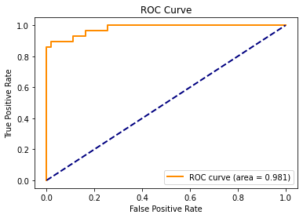

```python
plot_roc(fpr, tpr, auc)
```

### 4.3. Reduced Logistic Regression Model 1

Next, we will use a LASSO logistic regression to give us suggestions about what a good reduced logistic regression model might be to test.

#### 4.3.1. Fitting a LASSO Logistic Regression with $\lambda=100$

Next, use your training features matrix and target array to fit a LASSO logistic regression model using:

- the liblinear solver,
- a regularization penalty parameter of $\lambda=100$,
- and a maximum number of solver iterations of 1000.

```python
X_train = df_train[['radius_mean', 'texture_mean', 'perimeter_mean', 'area_mean', 'smoothness_mean', 'compactness_mean', 'concavity_mean', 'concavepoints_mean', 'symmetry_mean', 'fractal_dimension_mean']]
X_train.head()
```

|  | radius_mean | texture_mean | perimeter_mean | area_mean | smoothness_mean | compactness_mean | concavity_mean | concavepoints_mean | symmetry_mean | fractal_dimension_mean |
| --- | --- | --- | --- | --- | --- | --- | --- | --- | --- | --- |
| 438 | -0.078755 | 0.072221 | -0.135476 | -0.177157 | -0.677515 | -0.777787 | -0.946385 | -0.670364 | -0.936900 | -0.860147 |
| 511 | 0.193899 | -1.068042 | 0.110841 | 0.073409 | -0.828386 | -1.026810 | -0.685995 | -0.606394 | -0.557202 | -1.320868 |
| 373 | 1.849702 | -0.451369 | 1.764216 | 1.934305 | -0.135234 | 0.061763 | 0.802271 | 1.044420 | -0.878485 | -1.136580 |
| 68 | -1.447987 | -0.456023 | -1.366651 | -1.150124 | 0.728714 | 0.700428 | 2.814833 | -0.133333 | 1.093024 | 2.503828 |
| 306 | -0.263364 | -0.807410 | -0.325363 | -0.334435 | -0.800631 | -0.982274 | -1.096530 | -1.177705 | -0.655777 | -0.546856 |

```python
X_train = pd.get_dummies(X_train, drop_first=True)
X_train.head()
```

|  | radius_mean | texture_mean | perimeter_mean | area_mean | smoothness_mean | compactness_mean | concavity_mean | concavepoints_mean | symmetry_mean | fractal_dimension_mean |
| --- | --- | --- | --- | --- | --- | --- | --- | --- | --- | --- |
| 438 | -0.078755 | 0.072221 | -0.135476 | -0.177157 | -0.677515 | -0.777787 | -0.946385 | -0.670364 | -0.936900 | -0.860147 |
| 511 | 0.193899 | -1.068042 | 0.110841 | 0.073409 | -0.828386 | -1.026810 | -0.685995 | -0.606394 | -0.557202 | -1.320868 |
| 373 | 1.849702 | -0.451369 | 1.764216 | 1.934305 | -0.135234 | 0.061763 | 0.802271 | 1.044420 | -0.878485 | -1.136580 |
| 68 | -1.447987 | -0.456023 | -1.366651 | -1.150124 | 0.728714 | 0.700428 | 2.814833 | -0.133333 | 1.093024 | 2.503828 |
| 306 | -0.263364 | -0.807410 | -0.325363 | -0.334435 | -0.800631 | -0.982274 | -1.096530 | -1.177705 | -0.655777 | -0.546856 |

```python
y_train = df_train['y']
y_train.head()
```

```
438    0
511    0
373    1
68     0
306    0
Name: y, dtype: int64
```

```python
X_test = df_test[['radius_mean', 'texture_mean', 'perimeter_mean', 'area_mean', 'smoothness_mean', 'compactness_mean', 'concavity_mean', 'concavepoints_mean', 'symmetry_mean', 'fractal_dimension_mean']]
X_test.head()
```

|  | radius_mean | texture_mean | perimeter_mean | area_mean | smoothness_mean | compactness_mean | concavity_mean | concavepoints_mean | symmetry_mean | fractal_dimension_mean |
| --- | --- | --- | --- | --- | --- | --- | --- | --- | --- | --- |
| 346 | -0.587140 | -0.090674 | -0.630582 | -0.596093 | -0.889588 | -0.879367 | -1.020585 | -1.042880 | -0.936900 | -0.328545 |
| 302 | 1.693494 | 1.063551 | 1.760097 | 1.684024 | 0.828346 | 1.505866 | 1.751427 | 2.039810 | 1.596855 | 1.685870 |
| 289 | -0.783110 | -0.093001 | -0.815526 | -0.736307 | -0.656877 | -1.028326 | -0.813679 | -0.701316 | 0.735232 | -0.460382 |
| 192 | -1.251733 | -0.248914 | -1.286742 | -1.043186 | -1.911524 | -1.533193 | -1.114873 | -1.261820 | -0.579108 | 0.237079 |
| 82 | 3.150487 | 1.307894 | 3.275896 | 3.478653 | 0.707364 | 3.073153 | 3.077232 | 3.497170 | 0.063458 | 0.711976 |

```python
X_test = pd.get_dummies(X_test, drop_first=True)
X_test.head()
```

|  | radius_mean | texture_mean | perimeter_mean | area_mean | smoothness_mean | compactness_mean | concavity_mean | concavepoints_mean | symmetry_mean | fractal_dimension_mean |
| --- | --- | --- | --- | --- | --- | --- | --- | --- | --- | --- |
| 346 | -0.587140 | -0.090674 | -0.630582 | -0.596093 | -0.889588 | -0.879367 | -1.020585 | -1.042880 | -0.936900 | -0.328545 |
| 302 | 1.693494 | 1.063551 | 1.760097 | 1.684024 | 0.828346 | 1.505866 | 1.751427 | 2.039810 | 1.596855 | 1.685870 |
| 289 | -0.783110 | -0.093001 | -0.815526 | -0.736307 | -0.656877 | -1.028326 | -0.813679 | -0.701316 | 0.735232 | -0.460382 |
| 192 | -1.251733 | -0.248914 | -1.286742 | -1.043186 | -1.911524 | -1.533193 | -1.114873 | -1.261820 | -0.579108 | 0.237079 |
| 82 | 3.150487 | 1.307894 | 3.275896 | 3.478653 | 0.707364 | 3.073153 | 3.077232 | 3.497170 | 0.063458 | 0.711976 |

```python
y_test = df_test['y']
y_test.head()
```

```
346    0
302    1
289    0
192    0
82     1
Name: y, dtype: int64
```

```python
lasso_mod_5 = LogisticRegression('l1', solver='liblinear', max_iter=1000, C=1/100)
lasso_mod_5.fit(X_train,y_train)
```

```
LogisticRegression(C=0.01, max_iter=1000, penalty='l1', solver='liblinear')
```

#### 4.3.2. Extracting the Slopes

Next, extract the slopes for this LASSO logistic regression model.

```python
df_slope = pd.DataFrame(lasso_mod_5.coef_.T, columns=['lasso_5_slopes'], index=X_train.columns)
df_slope
```

|  | lasso_5_slopes |
| --- | --- |
| radius_mean | 0.000000 |
| texture_mean | 0.000000 |
| perimeter_mean | 0.146011 |
| area_mean | 0.000000 |
| smoothness_mean | 0.000000 |
| compactness_mean | 0.000000 |
| concavity_mean | 0.000000 |
| concavepoints_mean | 0.640243 |
| symmetry_mean | 0.000000 |
| fractal_dimension_mean | 0.000000 |

#### 4.3.3. Interpreting the Slopes

What do the results of this LASSO logistic regression model with regularization penalty $\lambda=100$ suggest?

If we were to create a reduced model based on the resulting slope values of this model, which explanatory variables should be included in the model?

The results suggest that the explanatory variables of perimeter_mean and concavepoints_mean bring enough predictive power to warrant wanting them to be included while the rest had a slope of 0, meaning they weren't good for predicting.

#### 4.3.4. Fitting the Reduced Logistic Regression Model 1

Next, using the suggestions from 4.3.3 about which explanatory variables to delete from this reduced model 1, fit this reduced logistic regression model 1 **with the training dataset** and display the summary output table below.

```python
full_mod2=smf.logit('y~perimeter_mean+concavepoints_mean', data=df_train).fit()
full_mod2.summary()
```

```
Optimization terminated successfully.
         Current function value: 0.177845
         Iterations 9
```

Logit Regression Results

| Dep. Variable: | y | No. Observations: | 472 |
| --- | --- | --- | --- |
| Model: | Logit | Df Residuals: | 469 |
| Method: | MLE | Df Model: | 2 |
| Date: | Wed, 14 Dec 2022 | Pseudo R-squ.: | 0.7329 |
| Time: | 04:53:25 | Log-Likelihood: | -83.943 |
| converged: | True | LL-Null: | -314.23 |
| Covariance Type: | nonrobust | LLR p-value: | 9.729e-101 |

|  | coef | std err | z | P>\|z\| | [0.025 | 0.975] |
| --- | --- | --- | --- | --- | --- | --- |
| Intercept | -0.5076 | 0.201 | -2.527 | 0.012 | -0.901 | -0.114 |
| perimeter_mean | 2.5507 | 0.458 | 5.566 | 0.000 | 1.653 | 3.449 |
| concavepoints_mean | 3.2689 | 0.442 | 7.393 | 0.000 | 2.402 | 4.136 |

#### 4.3.5. Test Data Predictive Probabilities

Next, use this reduced logistic regression model 1 that you fit in 4.3.4 to calculate the predictive probabilities for the observations in the **test dataset.**

```python
df_test['phat_test'] = full_mod2.predict(exog=df_test)
df_test
```

|  | diagnosis | radius_mean | texture_mean | perimeter_mean | area_mean | smoothness_mean | compactness_mean | concavity_mean | concavepoints_mean | symmetry_mean | fractal_dimension_mean | y | phat_test |
| --- | --- | --- | --- | --- | --- | --- | --- | --- | --- | --- | --- | --- | --- |
| 346 | B | -0.587140 | -0.090674 | -0.630582 | -0.596093 | -0.889588 | -0.879367 | -1.020585 | -1.042880 | -0.936900 | -0.328545 | 0 | 0.003970 |
| 302 | M | 1.693494 | 1.063551 | 1.760097 | 1.684024 | 0.828346 | 1.505866 | 1.751427 | 2.039810 | 1.596855 | 1.685870 | 1 | 0.999976 |
| 289 | B | -0.783110 | -0.093001 | -0.815526 | -0.736307 | -0.656877 | -1.028326 | -0.813679 | -0.701316 | 0.735232 | -0.460382 | 0 | 0.007538 |
| 192 | B | -1.251733 | -0.248914 | -1.286742 | -1.043186 | -1.911524 | -1.533193 | -1.114873 | -1.261820 | -0.579108 | 0.237079 | 0 | 0.000365 |
| 82 | M | 3.150487 | 1.307894 | 3.275896 | 3.478653 | 0.707364 | 3.073153 | 3.077232 | 3.497170 | 0.063458 | 0.711976 | 1 | 1.000000 |
| ... | ... | ... | ... | ... | ... | ... | ... | ... | ... | ... | ... | ... | ... |
| 120 | B | -0.771749 | -1.970944 | -0.767334 | -0.715545 | -0.187185 | -0.710510 | -0.673942 | -0.585243 | -0.527994 | -0.236401 | 0 | 0.012396 |
| 197 | M | 1.122625 | 0.593484 | 1.047507 | 1.049789 | -1.611917 | -0.339629 | 0.269940 | 0.228557 | -0.151947 | -1.332209 | 1 | 0.948408 |
| 304 | B | -0.757549 | -0.262877 | -0.757036 | -0.716114 | -0.557245 | -0.519289 | -0.695035 | -0.874394 | -1.462636 | -0.052113 | 0 | 0.004982 |
| 439 | B | -0.030472 | -0.844644 | -0.097993 | -0.137624 | -1.188483 | -0.919734 | -0.852851 | -0.577763 | -0.812768 | -0.983478 | 0 | 0.066225 |
| 470 | B | -1.266786 | -0.186084 | -1.255437 | -1.040342 | -0.491062 | -0.791432 | -0.744752 | -0.871299 | 1.556694 | 0.188880 | 0 | 0.001417 |

84 rows × 13 columns

#### 4.3.6 ROC and AUC

Finally, display the ROC curve and AUC score for this **reduced logistic regression model 1** and the **test dataset**.

```python
fpr, tpr, score = roc_curve(y_true=df_test['y'], y_score=df_test['phat_test'])
auc = roc_auc_score(y_true=df_test['y'], y_score=df_test['phat_test'])
```

```python
def plot_roc(fpr, tpr, auc, lw=2):
    plt.plot(fpr, tpr, color='darkorange', lw=lw,
             label='ROC curve (area = '+str(round(auc,3))+')')
    plt.plot([0, 1], [0, 1], color='navy', lw=lw, linestyle='--')
    plt.xlabel('False Positive Rate')
    plt.ylabel('True Positive Rate')
    plt.title('ROC Curve')
    plt.legend(loc="lower right")
    plt.show()
```

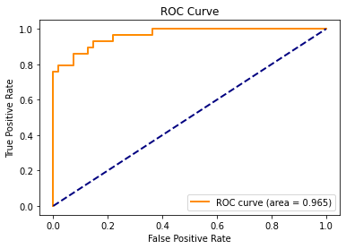

```python
plot_roc(fpr, tpr, auc)
```

#### 4.3.7. Logistic Regression Model

Write out the equation for this reduced logistic regression model 1. Make sure to use appropriate notation.

y = -0.5076 + 2.5507(perimeter_mean) + 3.2689(concavepoints_mean)

### 4.4. Reduced Logistic Regression Model 2

Next, we will use a LASSO logistic regression to give us suggestions about what a good reduced logistic regression model might be to test.

#### 4.4.1. Fitting a LASSO Logistic Regression with $\lambda=0.125$

Next, use your training features matrix and target array to fit a LASSO logistic regression model using:

- the liblinear solver,
- a regularization penalty parameter of $\lambda=0.125$,
- and a maximum number of solver iterations of 1000.

```python
lasso_mod_6 = LogisticRegression('l1', solver='liblinear', max_iter=1000, C=1/0.125)
lasso_mod_6.fit(X_train,y_train)
```

```
LogisticRegression(C=8.0, max_iter=1000, penalty='l1', solver='liblinear')
```

#### 4.4.2. Extracting the Slopes

Next, extract the slopes for this LASSO logistic regression model.

```python
df_slope2 = pd.DataFrame(lasso_mod_6.coef_.T, columns=['lasso_6_slopes'], index=X_train.columns)
df_slope2
```

|  | lasso_6_slopes |
| --- | --- |
| radius_mean | 0.000000 |
| texture_mean | 1.603961 |
| perimeter_mean | -0.007448 |
| area_mean | 4.169141 |
| smoothness_mean | 0.882481 |
| compactness_mean | -0.224909 |
| concavity_mean | 0.623444 |
| concavepoints_mean | 2.425223 |
| symmetry_mean | 0.594828 |
| fractal_dimension_mean | -0.212218 |

#### 4.4.3. Interpreting the Slopes

What do the results of this LASSO logistic regression model with regularization penalty $\lambda=0.125$ suggest?

If we were to create a reduced model based on the resulting slope values of this model, which explanatory variables should be included in the model?

#### 4.4.4. Fitting the Reduced Logistic Regression Model 2

Next, using the suggestions from 4.4.3 about which explanatory variables to delete from this reduced model 2, fit this reduced logistic regression model 2 **with the training dataset** and display the summary output table below.

```python
full_mod3=smf.logit('y~perimeter_mean+concavepoints_mean', data=df_train).fit()
full_mod3.summary()
```

```
Optimization terminated successfully.
         Current function value: 0.177845
         Iterations 9
```

Logit Regression Results

| Dep. Variable: | y | No. Observations: | 472 |
| --- | --- | --- | --- |
| Model: | Logit | Df Residuals: | 469 |
| Method: | MLE | Df Model: | 2 |
| Date: | Wed, 14 Dec 2022 | Pseudo R-squ.: | 0.7329 |
| Time: | 04:53:29 | Log-Likelihood: | -83.943 |
| converged: | True | LL-Null: | -314.23 |
| Covariance Type: | nonrobust | LLR p-value: | 9.729e-101 |

|  | coef | std err | z | P>\|z\| | [0.025 | 0.975] |
| --- | --- | --- | --- | --- | --- | --- |
| Intercept | -0.5076 | 0.201 | -2.527 | 0.012 | -0.901 | -0.114 |
| perimeter_mean | 2.5507 | 0.458 | 5.566 | 0.000 | 1.653 | 3.449 |
| concavepoints_mean | 3.2689 | 0.442 | 7.393 | 0.000 | 2.402 | 4.136 |

#### 4.4.5. Test Data Predictive Probabilities

Next, use this reduced logistic regression model 2 that you fit in 4.4.4 to calculate the predictive probabilities for the observations in the **test dataset.**

```python
df_test['phat_test'] = full_mod3.predict(exog=df_test)
df_test
```

|  | diagnosis | radius_mean | texture_mean | perimeter_mean | area_mean | smoothness_mean | compactness_mean | concavity_mean | concavepoints_mean | symmetry_mean | fractal_dimension_mean | y | phat_test |
| --- | --- | --- | --- | --- | --- | --- | --- | --- | --- | --- | --- | --- | --- |
| 346 | B | -0.587140 | -0.090674 | -0.630582 | -0.596093 | -0.889588 | -0.879367 | -1.020585 | -1.042880 | -0.936900 | -0.328545 | 0 | 0.003970 |
| 302 | M | 1.693494 | 1.063551 | 1.760097 | 1.684024 | 0.828346 | 1.505866 | 1.751427 | 2.039810 | 1.596855 | 1.685870 | 1 | 0.999976 |
| 289 | B | -0.783110 | -0.093001 | -0.815526 | -0.736307 | -0.656877 | -1.028326 | -0.813679 | -0.701316 | 0.735232 | -0.460382 | 0 | 0.007538 |
| 192 | B | -1.251733 | -0.248914 | -1.286742 | -1.043186 | -1.911524 | -1.533193 | -1.114873 | -1.261820 | -0.579108 | 0.237079 | 0 | 0.000365 |
| 82 | M | 3.150487 | 1.307894 | 3.275896 | 3.478653 | 0.707364 | 3.073153 | 3.077232 | 3.497170 | 0.063458 | 0.711976 | 1 | 1.000000 |
| ... | ... | ... | ... | ... | ... | ... | ... | ... | ... | ... | ... | ... | ... |
| 120 | B | -0.771749 | -1.970944 | -0.767334 | -0.715545 | -0.187185 | -0.710510 | -0.673942 | -0.585243 | -0.527994 | -0.236401 | 0 | 0.012396 |
| 197 | M | 1.122625 | 0.593484 | 1.047507 | 1.049789 | -1.611917 | -0.339629 | 0.269940 | 0.228557 | -0.151947 | -1.332209 | 1 | 0.948408 |
| 304 | B | -0.757549 | -0.262877 | -0.757036 | -0.716114 | -0.557245 | -0.519289 | -0.695035 | -0.874394 | -1.462636 | -0.052113 | 0 | 0.004982 |
| 439 | B | -0.030472 | -0.844644 | -0.097993 | -0.137624 | -1.188483 | -0.919734 | -0.852851 | -0.577763 | -0.812768 | -0.983478 | 0 | 0.066225 |
| 470 | B | -1.266786 | -0.186084 | -1.255437 | -1.040342 | -0.491062 | -0.791432 | -0.744752 | -0.871299 | 1.556694 | 0.188880 | 0 | 0.001417 |

84 rows × 13 columns

#### 4.4.6 ROC and AUC

Finally, display the ROC curve and AUC score for this **reduced logistic regression model 2** and the **test dataset**.

```python
fpr, tpr, score = roc_curve(y_true=df_test['y'], y_score=df_test['phat_test'])
auc = roc_auc_score(y_true=df_test['y'], y_score=df_test['phat_test'])
```

```python
def plot_roc(fpr, tpr, auc, lw=2):
    plt.plot(fpr, tpr, color='darkorange', lw=lw,
             label='ROC curve (area = '+str(round(auc,3))+')')
    plt.plot([0, 1], [0, 1], color='navy', lw=lw, linestyle='--')
    plt.xlabel('False Positive Rate')
    plt.ylabel('True Positive Rate')
    plt.title('ROC Curve')
    plt.legend(loc="lower right")
    plt.show()
```

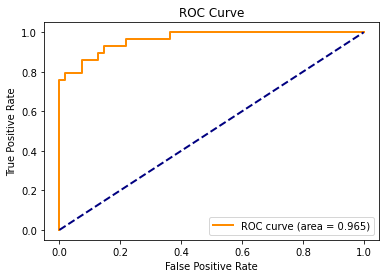

```python
plot_roc(fpr, tpr, auc)
```

### 4.5. Evaluating Models

Finally, let's evaluate the three logistic regression models that we just fit, with respect to how well they might perform with *new datasets*.

#### 4.5.1. Classifier Performance with New Datasets

Which model (full model, reduced model 1, or reduced model 2) does our analysis so far suggest will have the best classifier performance with *new datasets*? Explain.

The full model since it had the highest AUC score

#### 4.5.2. Model Parsimoniousness

Which of the three logistic regression models is the most parsimonious? Use the AIC score to help determine this.

```python
full_mod.aic
```

```
141.22328349573542
```

```python
full_mod2.aic
```

```
173.88608896478064
```

```python
full_mod3.aic
```

```
173.88608896478064
```

#### 4.5.3. Log Likelihood Ratio Test

Using the full model from 4.2 and the most parsimonious reduced model that you selected from 4.5.2., let's conduct a log-likelihood ratio test to test whether we have sufficient evidence to suggest the explanatory variable(s) that are in the full model (but not the reduced model) bring enough predictive power to the model.

##### 4.5.3.1. Hypotheses

Set up the hypotheses for this test.

Hypothesis: The explanatory variables in the full model bring enough predictive power to the model Alternative Hypothesis: The explanatory variables in the full model don't bring enough predictive power to the model

##### 4.5.3.2. Test Statistic

Calculate the test statistic for this test.

```python
full_mod.llf, full_mod2.llf
```

```
(-59.61164174786771, -83.94304448239032)
```

##### 4.5.3.3. p-value

Calulate the p-value for this test.

```python
full_mod.df_model, full_mod2.df_model
```

```
(10.0, 2.0)
```

##### 4.5.3.4. Conclusion

Make a conclusion with your p-value and a significance level of $\alpha=0.05$.

#### 4.5.4. Evaluation Agreement

Do our conclusions that we made in 4.5.1, 4.5.2, and 4.5.3 all agree with respect to which model we think will perform the best for *new datasets*?

Yes

### 4.6. Final Classifier

Finally, let's build our classifier. Select the logistic regression model (full model, reduced model1, or reduced model 2) that had the best performance identified in 4.5.1.

#### 4.6.1. Predictive Probability Threshold

Suppose that we would like for our classifier to correctly identify malignant tumors 100% of the time. Ideally, we would also like for our misclassification rate of benign tumors to be as low as it can possibly be, while still giving us 100% accuracy when identifying malignant tumors.

Using the logistic regression model that you selected from 4.5.1, select the predictive probability threshold that will best meet our classifier goals *with respect to the test dataset*.

**Give the sensitivity and specificity of the test dataset classifications using this predictive probability threshold that you selected.**

```python
def tpr_fpr_thresh(y, pred_prob, thresh):
    yhat = 1*(pred_prob >= thresh)
    tn, fp, fn, tp = confusion_matrix(y_true=y, y_pred=yhat).ravel()
    tpr = tp / (fn + tp)
    fpr = fp / (fp + tn)
    return pd.DataFrame({'threshold':[thresh],
                         'tpr':[tpr],
                         'fpr':[fpr]})
```

```python
for thresh in np.arange(0,1,.01):
    print(tpr_fpr_thresh(df_test['y'], df_test['phat_test'], thresh))
```

```
   threshold  tpr  fpr
0        0.0  1.0  1.0
   threshold  tpr       fpr
0       0.01  1.0  0.381818
   threshold  tpr       fpr
0       0.02  1.0  0.309091
   threshold  tpr       fpr
0       0.03  1.0  0.254545
   threshold       tpr       fpr
0       0.04  0.965517  0.218182
   threshold       tpr       fpr
0       0.05  0.965517  0.163636
   threshold       tpr       fpr
0       0.06  0.931034  0.163636
   threshold       tpr       fpr
0       0.07  0.931034  0.163636
   threshold       tpr       fpr
0       0.08  0.931034  0.145455
   threshold       tpr       fpr
0       0.09  0.931034  0.145455
   threshold       tpr       fpr
0        0.1  0.931034  0.145455
   threshold       tpr       fpr
0       0.11  0.931034  0.145455
   threshold       tpr       fpr
0       0.12  0.931034  0.145455
   threshold       tpr       fpr
0       0.13  0.931034  0.109091
   threshold       tpr       fpr
0       0.14  0.931034  0.109091
   threshold       tpr       fpr
0       0.15  0.931034  0.109091
   threshold       tpr       fpr
0       0.16  0.931034  0.109091
   threshold       tpr       fpr
0       0.17  0.931034  0.109091
   threshold       tpr       fpr
0       0.18  0.931034  0.109091
   threshold       tpr       fpr
0       0.19  0.931034  0.109091
```

[output cut: 145 more lines]

```
0       0.92  0.827586  0.0
   threshold       tpr  fpr
0       0.93  0.793103  0.0
   threshold       tpr  fpr
0       0.94  0.793103  0.0
   threshold       tpr  fpr
0       0.95  0.758621  0.0
   threshold       tpr  fpr
0       0.96  0.758621  0.0
   threshold       tpr  fpr
0       0.97  0.724138  0.0
   threshold       tpr  fpr
0       0.98  0.724138  0.0
   threshold       tpr  fpr
0       0.99  0.724138  0.0
```

```python
sensitivity = tp/(tp+fn)
sensitivity
```

[output not shown]

```python
specificity = tn/(tn+fp)
specificity
```

[output not shown]

#### 4.6.2 Final Classifications

For the observations in your test dataset (using the predictive probability threshold that you selected in 4.6.1):

- what **number** of malignant tissue samples were correctly identified as malignant?
- what **number** of benign tissue samples were correctly identified as benign?
- what **number** of malignant tissue samples were incorrectly identified as benign?
- what **number** of benign tissue samples were incorrectly identified as malignant?

```python
df_test['phat_test'] = full_mod.predict(exog=df_test)
df_test['yhat'] = 1*(df_test['phat_test'] >= 0.52)
tn, fp, fn, tp = confusion_matrix(y_true=df_test['y'], y_pred=df_test['yhat']).ravel()
print(tn, fp, fn, tp)
```

```
52 3 3 26
```

### 4.7. Additional Logistic Regression Interpretation and Inference

Select the logistic regression model that you picked in 4.5.1 to answer these questions.

#### 4.7.1. No-Multicollinearity Condition

Is the no-mutlicollinearity condition met for this logistic regression model that you picked? Is it possible that your logistic regression model slopes are biased?

```python
full_mod.summary()
```

Logit Regression Results

| Dep. Variable: | y | No. Observations: | 472 |
| --- | --- | --- | --- |
| Model: | Logit | Df Residuals: | 461 |
| Method: | MLE | Df Model: | 10 |
| Date: | Wed, 14 Dec 2022 | Pseudo R-squ.: | 0.8103 |
| Time: | 05:47:54 | Log-Likelihood: | -59.612 |
| converged: | True | LL-Null: | -314.23 |
| Covariance Type: | nonrobust | LLR p-value: | 4.691e-103 |

|  | coef | std err | z | P>\|z\| | [0.025 | 0.975] |
| --- | --- | --- | --- | --- | --- | --- |
| Intercept | 0.4551 | 0.624 | 0.729 | 0.466 | -0.769 | 1.679 |
| radius_mean | -7.5347 | 14.082 | -0.535 | 0.593 | -35.135 | 20.065 |
| texture_mean | 1.6449 | 0.315 | 5.216 | 0.000 | 1.027 | 2.263 |
| perimeter_mean | -0.8997 | 13.051 | -0.069 | 0.945 | -26.480 | 24.680 |
| area_mean | 13.6029 | 6.480 | 2.099 | 0.036 | 0.902 | 26.304 |
| smoothness_mean | 0.8898 | 0.485 | 1.834 | 0.067 | -0.061 | 1.841 |
| compactness_mean | 0.2449 | 1.143 | 0.214 | 0.830 | -1.996 | 2.486 |
| concavity_mean | 0.3280 | 0.731 | 0.449 | 0.653 | -1.104 | 1.760 |
| concavepoints_mean | 2.8074 | 1.203 | 2.334 | 0.020 | 0.450 | 5.165 |
| symmetry_mean | 0.5612 | 0.315 | 1.783 | 0.075 | -0.056 | 1.178 |
| fractal_dimension_mean | -0.4622 | 0.686 | -0.673 | 0.501 | -1.808 | 0.883 |

Possibly complete quasi-separation: A fraction 0.19 of observations can be  
perfectly predicted. This might indicate that there is complete  
quasi-separation. In this case some parameters will not be identified.

#### 4.7.2. Changing the Odds of a Malignant Tumor

If we were to increase the texture mean of a tissue sample by 1 unit (in the model that you selected), hold every other explanatory variable constant, by what multiple would we expect the **odds** of the tissue sample being malignant to change?

```python
np.exp(1.6449)
```

```
5.180491831861997
```

#### 4.7.3. Odds Multiplier Confidence Interval

Create a 99% confidence interval for the **odds multiplier of texture mean** in the corresponding population logistic regression model that you selected in 5.2.1.

```python
pe = 1.6449
stde = 0.315
cv = norm.ppf(0.995)
lower_bound = pe - cv*stde
upper_bound = pe + cv*stde
print(lower_bound, upper_bound)
```

```
0.8335137693820964 2.456286230617904
```

```python
odds_lower_bound = np.exp(lower_bound)
odds_upper_bound = np.exp(upper_bound)
```

```python
print(odds_lower_bound, odds_upper_bound)
```

```
2.3013911073497586 11.661423186298162
```

#### 4.7.4. Linear Association between the Log-Odds of a Tumor Being Malignant and Texture Mean in the Population

Finally, we would like to determine if we have sufficient evidence to suggest that there is a linear association between the log-odds of a breast tumor being malignant and the texture mean in the population of ALL brest tumors.

To help us answer this, we would like to determine if we have sufficient evidence to suggest that the odds multiplier for texture mean in the corresponding population logistic regression model is not equal to 1.

##### 4.7.4.1. Hypotheses

Set up the hypotheses for this test. Make sure you define any parameters that you use.

Hypothesis: There is a linear association between the log-odds of a breast tumor being malignant and the texture mean in the population of ALL brest tumors. Alternative: There isn't a linear association between the log-odds of a breast tumor being malignant and the texture mean in the population of ALL brest tumors.

##### 4.7.4.2. Conclusion

Use your confidence interval from 4.7.3 to make a conclusion about your hypotheses.

We are 99% confident that the odds multiplier for texture_mean in the corresponding population logistic regression model is between 2.3013911073497586 and 11.661423186298162.

#### 4.7.5. Predictions

##### 4.7.5.1. Probability Prediction

Predict the **probability** that a breast tumor with the following physical attributes is **malignant**.

- radius_mean: 0.47
- texture_mean: -0.33
- perimeter_mean: 0.48
- area_mean: 0.36
- smoothness_mean: 0.05
- compactness_mean: 0.47
- concavity_mean: 0.13
- concavepoints_mean: 0.44
- symmetry_mean: 0.11
- fractal_dimension_mean: -0.28

```python
probability_mal = 0.4551 - 7.5347*(0.47) + 1.6449*(-0.33) - 0.8997*(0.48) + 13.6029*(0.36) + 0.8898*(0.05) + 0.2449*(0.47) + 0.328*(0.13) + 2.8074*(0.44) + 0.5612*(0.11) - 0.4622*(-0.28)
probability_mal
```

```
2.4647990000000006
```

##### 4.7.5.2. Odds Prediction

Predict the **odds** that this observation from 4.7.5.1 is a malignant tumor. Put these odds into "prose format" (ie. the predicted odds that this tissue sample is malignant are xxx to yyy).

```python
prob_mal_odds = np.exp(probability_mal)
prob_mal_odds
```

```
11.761117929680127
```

## 5. Linear Regression - for Malignant Tumors

Finally, suppose we would like to learn more about how the physical attributes relate to each other **just for malignant tumors**. Specifically we would like to build a linear regression model that **predicts the texture mean** of malignant tumors given *some* of the remaining 9 physical attributes, ie:

- One that visualizes the relationship between diagnosis and radius_mean
- One that visualizes the relationship between diagnosis and perimeter_mean
- One that visualizes the relationship between diagnosis and area_mean
- One that visualizes the relationship between diagnosis and smoothness_mean
- One that visualizes the relationship between diagnosis and compactness_mean
- One that visualizes the relationship between diagnosis and concavity_mean
- One that visualizes the relationship between diagnosis and concavepoints_mean
- One that visualizes the relationship between diagnosis and symmetry_mean
- One that visualizes the relationship between diagnosis and fractal_dimension_mean

Specifically, we would like to build a linear regresison model that will yield accurate predictions for *new datasets*.

### 5.1. Dataframe Manipulation

First, let's create some new dataframes that we will use to fit our linear regression models below.

#### 5.1.1. Malignant Tumors Dataframe

First, create a dataframe that is comprised of just the malignant tumors.

```python
df_maligant = dfc[dfc['diagnosis'] == 'M'].reset_index(drop=True)
df_maligant
```

|  | diagnosis | radius_mean | texture_mean | perimeter_mean | area_mean | smoothness_mean | compactness_mean | concavity_mean | concavepoints_mean | symmetry_mean | fractal_dimension_mean | y |
| --- | --- | --- | --- | --- | --- | --- | --- | --- | --- | --- | --- | --- |
| 0 | M | 1.097064 | -2.073335 | 1.269934 | 0.984375 | 1.568466 | 3.283515 | 2.652874 | 2.532475 | 2.217515 | 2.255747 | 1 |
| 1 | M | 1.829821 | -0.353632 | 1.685955 | 1.908708 | -0.826962 | -0.487072 | -0.023846 | 0.548144 | 0.001392 | -0.868652 | 1 |
| 2 | M | 1.579888 | 0.456187 | 1.566503 | 1.558884 | 0.942210 | 1.052926 | 1.363478 | 2.037231 | 0.939685 | -0.398008 | 1 |
| 3 | M | -0.768909 | 0.253732 | -0.592687 | -0.764464 | 3.283553 | 3.402909 | 1.915897 | 1.451707 | 2.867383 | 4.910919 | 1 |
| 4 | M | 1.750297 | -1.151816 | 1.776573 | 1.826229 | 0.280372 | 0.539340 | 1.371011 | 1.428493 | -0.009560 | -0.562450 | 1 |
| ... | ... | ... | ... | ... | ... | ... | ... | ... | ... | ... | ... | ... |
| 205 | M | 1.929226 | 1.349781 | 2.101976 | 1.968434 | 0.963560 | 2.260135 | 2.870075 | 2.540213 | 1.231760 | 0.849484 | 1 |
| 206 | M | 2.110995 | 0.721473 | 2.060786 | 2.343856 | 1.041842 | 0.219060 | 1.947285 | 2.320965 | -0.312589 | -0.931027 | 1 |
| 207 | M | 1.704854 | 2.085134 | 1.615931 | 1.723842 | 0.102458 | -0.017833 | 0.693043 | 1.263669 | -0.217664 | -1.058611 | 1 |
| 208 | M | 0.702284 | 2.045574 | 0.672676 | 0.577953 | -0.840484 | -0.038680 | 0.046588 | 0.105777 | -0.809117 | -0.895587 | 1 |
| 209 | M | 1.838341 | 2.336457 | 1.982524 | 1.735218 | 1.525767 | 3.272144 | 3.296944 | 2.658866 | 2.137194 | 1.043695 | 1 |

210 rows × 12 columns

#### 5.1.2. Malignant Features Matrix and Target Array

Next, use your malignant tumors dataset from 5.1.1 to create a corresponding features matrix and target array for your linear regression models.

```python
X = df_maligant[['radius_mean', 'perimeter_mean', 'area_mean', 'smoothness_mean', 'compactness_mean', 'concavity_mean', 'concavepoints_mean', 'symmetry_mean', 'fractal_dimension_mean']]
X
```

|  | radius_mean | perimeter_mean | area_mean | smoothness_mean | compactness_mean | concavity_mean | concavepoints_mean | symmetry_mean | fractal_dimension_mean |
| --- | --- | --- | --- | --- | --- | --- | --- | --- | --- |
| 0 | 1.097064 | 1.269934 | 0.984375 | 1.568466 | 3.283515 | 2.652874 | 2.532475 | 2.217515 | 2.255747 |
| 1 | 1.829821 | 1.685955 | 1.908708 | -0.826962 | -0.487072 | -0.023846 | 0.548144 | 0.001392 | -0.868652 |
| 2 | 1.579888 | 1.566503 | 1.558884 | 0.942210 | 1.052926 | 1.363478 | 2.037231 | 0.939685 | -0.398008 |
| 3 | -0.768909 | -0.592687 | -0.764464 | 3.283553 | 3.402909 | 1.915897 | 1.451707 | 2.867383 | 4.910919 |
| 4 | 1.750297 | 1.776573 | 1.826229 | 0.280372 | 0.539340 | 1.371011 | 1.428493 | -0.009560 | -0.562450 |
| ... | ... | ... | ... | ... | ... | ... | ... | ... | ... |
| 205 | 1.929226 | 2.101976 | 1.968434 | 0.963560 | 2.260135 | 2.870075 | 2.540213 | 1.231760 | 0.849484 |
| 206 | 2.110995 | 2.060786 | 2.343856 | 1.041842 | 0.219060 | 1.947285 | 2.320965 | -0.312589 | -0.931027 |
| 207 | 1.704854 | 1.615931 | 1.723842 | 0.102458 | -0.017833 | 0.693043 | 1.263669 | -0.217664 | -1.058611 |
| 208 | 0.702284 | 0.672676 | 0.577953 | -0.840484 | -0.038680 | 0.046588 | 0.105777 | -0.809117 | -0.895587 |
| 209 | 1.838341 | 1.982524 | 1.735218 | 1.525767 | 3.272144 | 3.296944 | 2.658866 | 2.137194 | 1.043695 |

210 rows × 9 columns

```python
y = df_maligant['texture_mean']
y
```

```
0     -2.073335
1     -0.353632
2      0.456187
3      0.253732
4     -1.151816
         ...
205    1.349781
206    0.721473
207    2.085134
208    2.045574
209    2.336457
Name: texture_mean, Length: 210, dtype: float64
```

### 5.2. Cross-Fold Validation

In order to help us determine which explanatory variables to include in our malignant tumor linear regression model that will yield good predictions for new datasets, we will try out the following four linear regression models.

1. Non-Regularized Linear Regression
2. LASSO Linear Regression with $\lambda=0.0025$
3. LASSO Linear Regression with $\lambda=0.01$
4. LASSO Linear Regression with $\lambda=10$

For each of these models we will use k=5 crossfold validation to evaluate the 5 test fold performance.

#### 5.2.1. Non-Regularized Linear Regression

Perform k=5 crossfold validation on a non-regularized linear regression model that predicts texture mean with the remaining 9 physical attributes.

Calculate the average mean squared error for each of the 5 test folds.

```python
from sklearn.model_selection import cross_val_score

finalmod = LinearRegression()
scores0 = cross_val_score(finalmod, X, y, cv=5, scoring="neg_mean_squared_error")
print("Average MSE:", round(-scores0.mean(), 2))
```

```
Average MSE: 0.75
```

#### 5.2.2. LASSO Linear Regression with $\lambda=0.0025$

Perform k=5 crossfold validation on a LASSO linear regression model with $\lambda=0.0025$ that predicts texture mean with the remaining 9 physical attributes. Use a maximum number of solver iterations of 1000.

Calculate the average mean squared error for each of the 5 test folds.

```python
from sklearn.linear_model import LassoCV
final_lm1 = LassoCV(max_iter = 1000, cv=5, alphas=[0.0025, 0.0025, 0.0025, 0.0025, 0.0025, 0.0025]).fit(X, y)

df_final_lm1 = pd.DataFrame(final_lm1.mse_path_, index=final_lm1.alphas_, columns=['test_fold_%s_avg_MSE'%(str(i)) for i in range(1, 6)])
df_final_lm1.iloc[4,:].mean()
```

```
0.7344302894358418
```

#### 5.2.3. LASSO Linear Regression with $\lambda=0.01$

Perform k=5 crossfold validation on a LASSO linear regression model with $\lambda=0.01$ that predicts texture mean with the remaining 9 physical attributes. Use a maximum number of solver iterations of 1000.

Calculate the average mean squared error for each of the 5 test folds.

```python
from sklearn.linear_model import LassoCV
final_lm2 = LassoCV(max_iter = 1000, cv=5, alphas=[0.01, 0.01, 0.01, 0.01, 0.01, 0.01]).fit(X, y)

df_final_lm2 = pd.DataFrame(final_lm2.mse_path_, index=final_lm2.alphas_, columns=['test_fold_%s_avg_MSE'%(str(i)) for i in range(1, 6)])
df_final_lm2.iloc[4,:].mean()
```

```
0.7368416551737894
```

#### 5.2.4. LASSO Linear Regression with $\lambda=10$

Perform k=5 crossfold validation on a LASSO linear regression model with $\lambda=10$ that predicts texture mean with the remaining 9 physical attributes. Use a maximum number of solver iterations of 1000.

Calculate the average mean squared error for each of the 5 test folds.

```python
from sklearn.linear_model import LassoCV
final_lm3 = LassoCV(max_iter = 1000, cv=5, alphas=[10, 10, 10, 10, 10, 10]).fit(X, y)

df_final_lm3 = pd.DataFrame(final_lm3.mse_path_, index=final_lm3.alphas_, columns=['test_fold_%s_avg_MSE'%(str(i)) for i in range(1, 6)])
df_final_lm3.iloc[4,:].mean()
```

```
0.7831816066876264
```

#### 5.2.5. Model Selection

Which linear regression model of the four that were tested above in 5.2.1-5.2.4 does the analysis suggest will have the most accurate predictions for *new datasets*?

The linear regression model that the analysis suggest will have the most accurate predictions for new datasets is 5.2.2, LASSO Linear Regression with λ = 0.0025

#### 5.2.6. Fitting the Best Model and Extracting the Slopes

Select the best model that you chose in 5.2.5 and fit this model with the whole malignant tumor features matrix and whole malignant tumor target array. Then display the resulting slopes for this model.

```python
best_model = LassoCV(max_iter = 1000, cv=5, alphas=[0.0025, 0.0025, 0.0025, 0.0025, 0.0025, 0.0025]).fit(X, y)
```

```python
pd.DataFrame(best_model.coef_, columns=['Best_LASSO_Slopes'], index=X.columns)
```

|  | Best_LASSO_Slopes |
| --- | --- |
| radius_mean | 0.000000 |
| perimeter_mean | 0.000000 |
| area_mean | 0.000000 |
| smoothness_mean | -0.316890 |
| compactness_mean | 0.094205 |
| concavity_mean | 0.415919 |
| concavepoints_mean | -0.239888 |
| symmetry_mean | -0.125912 |
| fractal_dimension_mean | 0.038250 |

#### 5.2.7. Best Model Slopes Interpretation

What do the resulting slopes of this regression model suggest?

If we were to create a reduced model based on the resulting slope values of this model, which explanatory variables should be included in the model?

The slopes suggest smoothness_mean, compactness_mean, concavity_mean, concavepoints_mean, symmetry_mean, and fractal_dimension_mean should be in the reduced model as the other slopes are 0

### 5.3. Model Comparison

#### 5.3.1. Full Model Fit

Fit the 'full linear regression model' (ie. the linear regression model that predicts texture_mean given all 9 remaining physical attributes.) with the full malignant tumors dataset. Show the summary output table for this model below.

```python
final_full_mod = smf.ols('texture_mean~radius_mean+perimeter_mean+area_mean+smoothness_mean+compactness_mean+concavity_mean+concavepoints_mean+symmetry_mean+fractal_dimension_mean', data=df_maligant).fit()
final_full_mod.summary()
```

OLS Regression Results

| Dep. Variable: | texture_mean | R-squared: | 0.094 |
| --- | --- | --- | --- |
| Model: | OLS | Adj. R-squared: | 0.054 |
| Method: | Least Squares | F-statistic: | 2.316 |
| Date: | Wed, 14 Dec 2022 | Prob (F-statistic): | 0.0169 |
| Time: | 11:51:17 | Log-Likelihood: | -259.78 |
| No. Observations: | 210 | AIC: | 539.6 |
| Df Residuals: | 200 | BIC: | 573.0 |
| Df Model: | 9 |  |  |
| Covariance Type: | nonrobust |  |  |

|  | coef | std err | t | P>\|t\| | [0.025 | 0.975] |
| --- | --- | --- | --- | --- | --- | --- |
| Intercept | 0.5474 | 0.120 | 4.578 | 0.000 | 0.312 | 0.783 |
| radius_mean | -1.0669 | 1.802 | -0.592 | 0.554 | -4.620 | 2.486 |
| perimeter_mean | 1.2737 | 1.976 | 0.645 | 0.520 | -2.623 | 5.170 |
| area_mean | -0.0957 | 0.450 | -0.213 | 0.832 | -0.983 | 0.792 |
| smoothness_mean | -0.2998 | 0.147 | -2.036 | 0.043 | -0.590 | -0.009 |
| compactness_mean | 0.0052 | 0.242 | 0.021 | 0.983 | -0.473 | 0.483 |
| concavity_mean | 0.4163 | 0.215 | 1.933 | 0.055 | -0.008 | 0.841 |
| concavepoints_mean | -0.3147 | 0.258 | -1.219 | 0.224 | -0.824 | 0.194 |
| symmetry_mean | -0.1257 | 0.087 | -1.444 | 0.150 | -0.297 | 0.046 |
| fractal_dimension_mean | 0.0603 | 0.163 | 0.369 | 0.712 | -0.262 | 0.382 |

| Omnibus: | 36.997 | Durbin-Watson: | 1.870 |
| --- | --- | --- | --- |
| Prob(Omnibus): | 0.000 | Jarque-Bera (JB): | 96.979 |
| Skew: | 0.753 | Prob(JB): | 8.74e-22 |
| Kurtosis: | 5.969 | Cond. No. | 143. |

Notes:  
[1] Standard Errors assume that the covariance matrix of the errors is correctly specified.

#### 5.3.2. Reduced Model Fit

Use the suggestions about which explanatory variables to delete from 5.2.7 to fit a reduced linear regression model that predicts texture mean with the full malignant tumors dataset. Show the summary output table for this model below.

```python
final_red_mod = smf.ols('texture_mean~smoothness_mean+compactness_mean+concavity_mean+concavepoints_mean+symmetry_mean+fractal_dimension_mean', data=df_maligant).fit()
final_red_mod.summary()
```

OLS Regression Results

| Dep. Variable: | texture_mean | R-squared: | 0.092 |
| --- | --- | --- | --- |
| Model: | OLS | Adj. R-squared: | 0.066 |
| Method: | Least Squares | F-statistic: | 3.445 |
| Date: | Wed, 14 Dec 2022 | Prob (F-statistic): | 0.00292 |
| Time: | 11:52:02 | Log-Likelihood: | -260.01 |
| No. Observations: | 210 | AIC: | 534.0 |
| Df Residuals: | 203 | BIC: | 557.4 |
| Df Model: | 6 |  |  |
| Covariance Type: | nonrobust |  |  |

|  | coef | std err | t | P>\|t\| | [0.025 | 0.975] |
| --- | --- | --- | --- | --- | --- | --- |
| Intercept | 0.5464 | 0.097 | 5.634 | 0.000 | 0.355 | 0.738 |
| smoothness_mean | -0.3291 | 0.129 | -2.557 | 0.011 | -0.583 | -0.075 |
| compactness_mean | 0.0938 | 0.196 | 0.479 | 0.632 | -0.292 | 0.480 |
| concavity_mean | 0.4541 | 0.201 | 2.256 | 0.025 | 0.057 | 0.851 |
| concavepoints_mean | -0.2715 | 0.179 | -1.517 | 0.131 | -0.624 | 0.081 |
| symmetry_mean | -0.1329 | 0.084 | -1.580 | 0.116 | -0.299 | 0.033 |
| fractal_dimension_mean | 0.0445 | 0.147 | 0.304 | 0.762 | -0.244 | 0.333 |

| Omnibus: | 34.796 | Durbin-Watson: | 1.859 |
| --- | --- | --- | --- |
| Prob(Omnibus): | 0.000 | Jarque-Bera (JB): | 87.301 |
| Skew: | 0.722 | Prob(JB): | 1.10e-19 |
| Kurtosis: | 5.809 | Cond. No. | 12.1 |

Notes:  
[1] Standard Errors assume that the covariance matrix of the errors is correctly specified.

#### 5.3.3. Comparing and Assessing Model Fits

Which of these two linear regression models provided a better fit of the full dataset of malignant tumors that was used to train the models? Was the fit of either of these linear regression models good?

#### 5.3.4. Comparing Model Parsimoniousness

Which of these two linear regression models is more parsimonious? Explain?

```python
final_full_mod.aic
```

```
539.5631017173714
```

```python
final_red_mod.aic
```

```
534.0191799293558
```

The reduced model is more pasrimonious because it has a lower aic score

#### 5.3.5. Conclusion Agreement

When it comes to assessing how well a linear regression model will do when making predictions with new datasets, do your conclusions that you made in 5.2.5 and 5.3.4 agree with each other?

Yes

### 5.4. Reduced Model Inference

Let's conduct inference on the slopes in the reduced model from 5.3.2.

#### 5.4.1. At Least One Population Slope being Non-Zero

First, we would like to determine if we have sufficient evidence to suggest if at least one of the corresponding population slopes in the reduced model is non-zero.

##### 5.4.1.1. Hypotheses

Set up the hyptheses for this test.

Hypothesis: None of the corresponding population slopes in the reduced model is non-zero.  
Alternative: At least one of the corresponding population slopes in the reduced model is non-zero.

#### 5.4.1.2. Test Statistic and p-value

Write down the test statistic and p-value for this hypothesis test.

```python
final_red_mod.summary()
```

OLS Regression Results

| Dep. Variable: | texture_mean | R-squared: | 0.092 |
| --- | --- | --- | --- |
| Model: | OLS | Adj. R-squared: | 0.066 |
| Method: | Least Squares | F-statistic: | 3.445 |
| Date: | Wed, 14 Dec 2022 | Prob (F-statistic): | 0.00292 |
| Time: | 12:03:44 | Log-Likelihood: | -260.01 |
| No. Observations: | 210 | AIC: | 534.0 |
| Df Residuals: | 203 | BIC: | 557.4 |
| Df Model: | 6 |  |  |
| Covariance Type: | nonrobust |  |  |

|  | coef | std err | t | P>\|t\| | [0.025 | 0.975] |
| --- | --- | --- | --- | --- | --- | --- |
| Intercept | 0.5464 | 0.097 | 5.634 | 0.000 | 0.355 | 0.738 |
| smoothness_mean | -0.3291 | 0.129 | -2.557 | 0.011 | -0.583 | -0.075 |
| compactness_mean | 0.0938 | 0.196 | 0.479 | 0.632 | -0.292 | 0.480 |
| concavity_mean | 0.4541 | 0.201 | 2.256 | 0.025 | 0.057 | 0.851 |
| concavepoints_mean | -0.2715 | 0.179 | -1.517 | 0.131 | -0.624 | 0.081 |
| symmetry_mean | -0.1329 | 0.084 | -1.580 | 0.116 | -0.299 | 0.033 |
| fractal_dimension_mean | 0.0445 | 0.147 | 0.304 | 0.762 | -0.244 | 0.333 |

| Omnibus: | 34.796 | Durbin-Watson: | 1.859 |
| --- | --- | --- | --- |
| Prob(Omnibus): | 0.000 | Jarque-Bera (JB): | 87.301 |
| Skew: | 0.722 | Prob(JB): | 1.10e-19 |
| Kurtosis: | 5.809 | Cond. No. | 12.1 |

Notes:  
[1] Standard Errors assume that the covariance matrix of the errors is correctly specified.

test-statistic = 3.445  
p-value = 0.00292

##### 5.4.1.3 Conclusion

Use this p-value and a significance level of $\alpha=0.05$ to make a conclusion about your hypotheses.

Since the p-value is lower than the significance level, we reject the null hypothesis. Thus there is sufficient evidence to suggest that at least one of the slopes is non-zero

#### 5.4.2. Which Population Slopes are Non-Zero

*Which* of the corresponding population slopes in the reduced model do we have sufficient evidence to suggest are non-zero? Explain. (Use a significance level of $\alpha=0.05$).

### 5.5. Reduced Model Equation and Prediction

#### 5.5.1. Linear Regression Equation

Write out the linear regression equation for your reduced model from 5.3.2. Make sure to use appropriate notation.

```python
final_red_mod.summary()
```

OLS Regression Results

| Dep. Variable: | texture_mean | R-squared: | 0.092 |
| --- | --- | --- | --- |
| Model: | OLS | Adj. R-squared: | 0.066 |
| Method: | Least Squares | F-statistic: | 3.445 |
| Date: | Wed, 14 Dec 2022 | Prob (F-statistic): | 0.00292 |
| Time: | 12:09:03 | Log-Likelihood: | -260.01 |
| No. Observations: | 210 | AIC: | 534.0 |
| Df Residuals: | 203 | BIC: | 557.4 |
| Df Model: | 6 |  |  |
| Covariance Type: | nonrobust |  |  |

|  | coef | std err | t | P>\|t\| | [0.025 | 0.975] |
| --- | --- | --- | --- | --- | --- | --- |
| Intercept | 0.5464 | 0.097 | 5.634 | 0.000 | 0.355 | 0.738 |
| smoothness_mean | -0.3291 | 0.129 | -2.557 | 0.011 | -0.583 | -0.075 |
| compactness_mean | 0.0938 | 0.196 | 0.479 | 0.632 | -0.292 | 0.480 |
| concavity_mean | 0.4541 | 0.201 | 2.256 | 0.025 | 0.057 | 0.851 |
| concavepoints_mean | -0.2715 | 0.179 | -1.517 | 0.131 | -0.624 | 0.081 |
| symmetry_mean | -0.1329 | 0.084 | -1.580 | 0.116 | -0.299 | 0.033 |
| fractal_dimension_mean | 0.0445 | 0.147 | 0.304 | 0.762 | -0.244 | 0.333 |

| Omnibus: | 34.796 | Durbin-Watson: | 1.859 |
| --- | --- | --- | --- |
| Prob(Omnibus): | 0.000 | Jarque-Bera (JB): | 87.301 |
| Skew: | 0.722 | Prob(JB): | 1.10e-19 |
| Kurtosis: | 5.809 | Cond. No. | 12.1 |

Notes:  
[1] Standard Errors assume that the covariance matrix of the errors is correctly specified.

texture_mean = 0.5464 - 0.3291(smoothness_mean) + 0.0938(compactness_mean) + 0.4541(concavity_mean) - 0.2715(concavepoints_mean) - 0.1329(symmetry_mean) + 0.0445(fractal_dimension_mean)

#### 5.5.2. Prediction

Predict the texture mean of the following breast tumor tissue sample using your linear regression model.

*(Note: you may not need to plug in all of this information).*

- radius_mean: 0.47
- texture_mean: -0.33
- perimeter_mean: 0.48
- area_mean: 0.36
- smoothness_mean: 0.05
- compactness_mean: 0.47
- concavity_mean: 0.13
- concavepoints_mean: 0.44
- symmetry_mean: 0.11
- fractal_dimension_mean: -0.28

```python
tm = 0.5464 - 0.3291*(0.05) + 0.0938*(0.47) + 0.4541*(0.13) - 0.2715*(0.44) - 0.1329*(0.11) + 0.0445*(-0.28)
tm
```

```
0.48652499999999993
```

#### 5.5.3. Residual

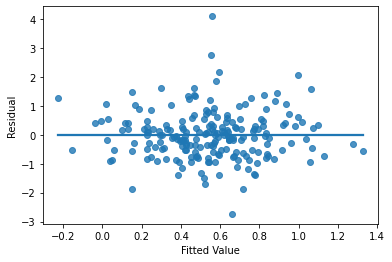

```python
sns.regplot(x=final_red_mod.fittedvalues, y=final_red_mod.resid, ci=None)
plt.ylabel("Residual")
plt.xlabel("Fitted Value")
plt.show()
```

# Part 2 Additional Conceptual Question

This final question in part 2 does not have anything to do with the previous breast tumor analysis from part 1.

## 6. Combinatorics and Probability

Suppose that a class of 100 students has 90 people that are right-handed and 10 people that are left-handed. What is the probability of randomly selecting a group of 5 students in which 2 are right-handed and 3 are left-handed.

Note: *The order/way in which we selected the students in this sample does not matter.*

Note: *I'm not looking for a simulated approximation for this probability. You should calculate the THEORETICAL probability here.*

```python
import math
```

```python
denom = math.factorial(100)/math.factorial(5)
```

```python
rh = (90*89)/(2*1)
```

```python
lh = (10*9*8)/(3*2*1)
```

```python
num = rh*lh
```

```python
theoretical = num/denom
theoretical
```

```
6.179614133677192e-151
```

# 🎉🎉🎉🎉Have a nice winter break! 🎉🎉🎉🎉

## Good luck in your careers as data scientists! Feel free to reach out!